# EC7025 - SFC

# Model with Portfolio choice

## Balance Sheet

|  | Households | Production | Government | Central Bank | Sum |
| --- | --- | --- | --- | --- | --- |
| Money | +H |  |  | -H | 0 |
| Bills | +Bh |  | -B | +Bcb | 0 |
| Net worth | -V |  | +V |  | 0 |
| Sum | 0 | 0 | 0 | 0 | 0 |

## Transaction Flow Matrix

|  | Households | Production | Government | Central Bank | Sum |
| --- | --- | --- | --- | --- | --- |
| Consumption | -C | +C |  |  | 0 |
| Gov. Exp. |  | +G | -G |  | 0 |
| Income = GDP | +Y | -Y |  |  | 0 |
| Interests | +r(-1)*Bh(-1) |  | -r(1)*B(-1) | +r(-1)*Bcb(-1) | 0 |
| CB profits |  |  | +r(-1)*Bcb(-1) | -r(1)*Bcb(-1) | 0 |
| Taxes | -T |  | +T |  | 0 |
| Change in Money | -$\Delta$ H |  |  | +$\Delta$ H | 0 |
| Change in Bills | -$\Delta$ Bh |  | +$\Delta$ B | -$\Delta$ Bcb | 0 |
| Sum | 0 | 0 | 0 | 0 | 0 |

## Behavioural Equations (from PC.txt file)

```r
#######Determination of output - eq. 4.1
y = cons + g
#######Disposable income - eq. 4.2
yd = y - t + r(-1)*b_h(-1)
#######Tax payments - eq. 4.3
t = theta*(y + r(-1)*b_h(-1))
#######Wealth accumulation - eq. 4.4
v = v(-1) + (yd - cons)
#######Consumption function - eq. 4.5
cons = alpha1*yd + alpha2*v(-1)
#######Cash money - eq. 4.6
h_h = v - b_h
#######Demand for government bills - eq. 4.7
b_h = v*(lambda0 + lambda1*r - lambda2*(yd/v))
#######Supply of government bills - eq. 4.8
b_s = b_s(-1) + (g + r(-1)*b_s(-1)) - (t + r(-1)*b_cb(-1))
#######Supply of cash - eq. 4.9
h_s = h_s(-1) + b_cb - b_cb(-1)
#######Government bills held by the central bank - eq. 4.10
b_cb = b_s - b_h
#######Interest rate as policy instrument - eq. 4.11
r = r_bar
```

## Portfolio Equations

How to allocate wealth between bills and money?

1. Quantity theory of money: links money balances to the flow of income
2. Liquidity preferences: money balances some proportion of total wealth

Merging the two into Tobin’s portfolio equations:

$$\begin{align}
\frac{H_h}{V}&=(1-\lambda_0)-\lambda_1\cdot r+\lambda_2\cdot\left(\frac{YD}{V}\right)\tag{4.6A}\\
\frac{B_h}{V}&=\lambda_0+\lambda_1\cdot r-\lambda_2\cdot\left(\frac{YD}{V}\right)\tag{4.7}\\
H_h&=V-B_h\tag{4.6}
\end{align}$$

## Setting up the environment

Before doing any modelling, we need to load the package in the R environment.

```r
library(PKSFC)
```

Then, you need to download the attached ‘PC.txt’ file and save it in the folder of your choice. Make sure to set the working directory where you saved the downloaded file. In command line this looks like this but if you use Rstudio, you can use the graphical interface as well (Session>Set Working Directory>Choose Directory)

```r
setwd("pathToYourDirectory")
```

## Loading the model

The first thing to do is to load the model and check for completeness.

```r
pc<-sfc.model("PC.txt",modelName="Portfolio Choice Model")
pc<-sfc.check(pc,fill=FALSE)
```

Let’s have a look at the graphical representation of model PC. In order to do so, we need to load the `Rgraphviz` library:

```r
library("Rgraphviz")
```

We can now look at the graph of model PC:

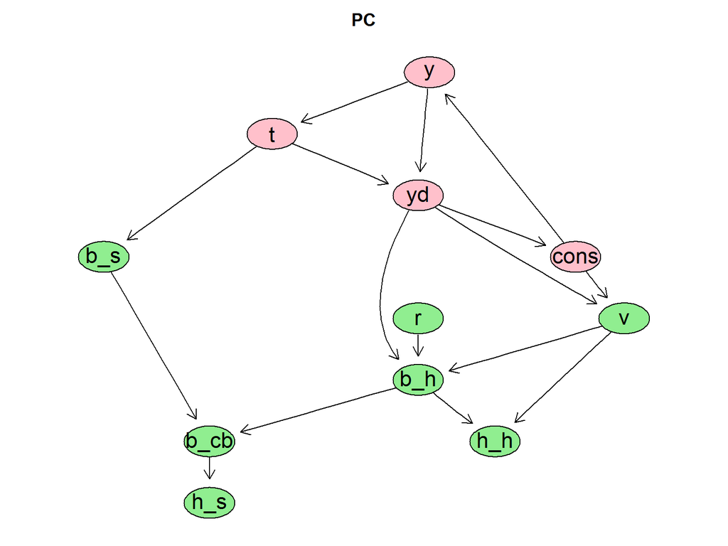

```r
plot.dag(pc,main="PC" )
```

You can see that there is a cycle in the graph, implying that GDP, taxes, disposable income and consumption are determined all together (and that they fully adapt to any shock applied to the economy). While this is a mathematical property of the system of equations representing the economy we wish to model, it has an economic meaning and you want to be sure that this is what you believe to be the best representation of what you have in mind.

We are now ready to simulate the model

```r
datapc<-simulate(pc)
```